# Running the simulation

Wed Feb 3 16:56:06 2016

## Setting up the simulation

First we need to decide where the loci under selection are. Here `qtl` is a named list, one element per chromosome, and each element of the list is a data frame whose columns give the name of the locus, the selection coefficient, and the position in Morgans.

```r
qtl=list(
         chr1=data.frame(
                    traits = c("underdominant"),
                    s = c(0.1),
                    pos = c(0.5)
                )
    )
```

Now, let’s set up the population, which means specifying the number of individuals, the number of demes, the width of the zone in real units, and the dispersal SD ($\sigma$). Our locus has a selection coefficient of 0.1, so the cline width will be about 3.2$\sigma$ wide; so we’ll take our zone to be four times that, and measure distance in units of $\sigma$:

```r
zone.width <- ceiling(4/sqrt(qtl[[1]]$s))  # in real units
n.ind <- 1000
n.deme <- 50
sigma <- 1 # in real units
deme.spacing <- zone.width/n.deme
deme.locs <- (seq_len(n.deme)-0.5-(n.deme/2))*deme.spacing
sigma.demes <- sigma/deme.spacing # in units of demes
```

The discretized dispersal kernel moves as $\lfloor Z+1/2 \rfloor$, where $Z \sim N(0,\sigma_\text{demes}^2)$; let’s check this has SD close to $\sigma$:

```r
zz <- floor( rnorm( 1e6, mean=1/2, sd=sigma.demes ) )*deme.spacing
sd(zz)
```

```
## [1] 1.003871
```

That’s pretty close.

## Running a simulation

The simulation doesn’t know how we’re measuring things in real units, so the sigma we pass needs to be in units of demes. It returns all the information about the individuals, but then we use `spBreaks()` to extract which individual is which ancestry.

```r
sim <- sim.zone( n.ind=n.ind, n.deme=n.deme, n.gen=10, sigma=sigma.demes, quiet=TRUE )
sim.sums <- spBreaks(sim)
```

Here `sim` is a list with five named components:

- **inds** is a list of length `ninds`,
  - each element of which is a list, one element per chromosome,
    - each element of which is a list with names “X1” and “X2”, corresponding to the two copies of the chromosome,
      - each element of which is a data frame, with columns:
        - **pos**: coordinates of recombination
        - **ancest**: ancestor ID
- **sp.inds** is a character vector of length `ninds`, giving the ancestral type of each ancestor (i.e., ancestries corresponding to the the ancestor IDs)
- **deme** is an integer vector of length `ninds`, giving the deme number of each individual (including the ancestors)
- **pars** is an integer that gives the number of generations of the simulation
- **QTL** returns the QTL vector used in the simulation

and `sim.sums` is a named list with components:

- **ind.ancestry**: a list of length `ninds`
  - each element of which is a list, one element per chromosome,
    - each element of which is a list with names “X1” and “X2”, corresponding to the two copies of the chromosome,
      - each element of which is a data frame, with variables
        - **starts**: start position of a chunk of ancestry
        - **stops**: end position of the chunk of ancestry
        - **sp2**: logical variable saying whether the chunk is of ancestry $A$ or not
- **ancest.prop**: is a `ninds*2` matrix giving the ancestry proportion of each individual on each of their two copies of the chromosome.

OK, now let’s genotype these individuals at some loci:

```r
loci <- seq(0,1,0.05)
loci.cols <- rainbow(12)[cut(abs(loci-0.5),breaks=min((length(loci)-1)/2,8))]
info <- data.frame(
               chr=1,
               bp=floor(loci*1e6),
               pos=loci
           )
genotypes <- geno.pop( sim.sums$ind.ancest, list(chr1=loci) )
```

Now, let’s compute ancestry frequencies, and plot the resulting clines:

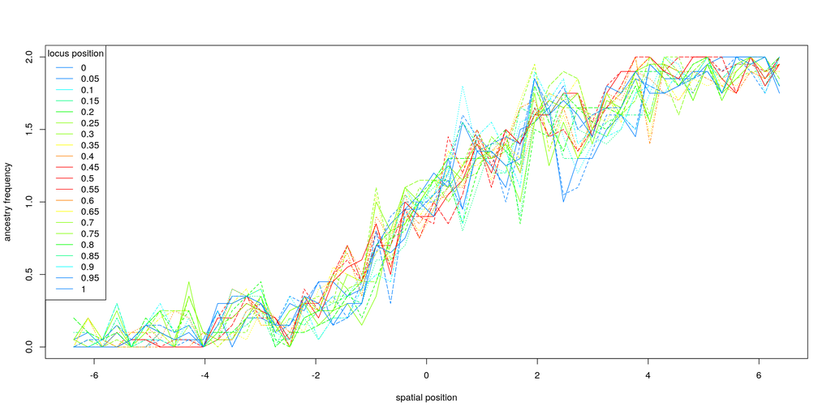

```r
freqs <- do.call( cbind, tapply( 1:ncol(genotypes), sim$deme, function (kk) {
                    rowMeans(genotypes[,kk])
                } ) )
matplot(deme.locs, t(freqs), type='l', col=loci.cols, xlab="spatial position", ylab="ancestry frequency")
legend("topleft",lty=1,legend=loci,col=loci.cols,title="locus position")
```

We can also look at the local frequencies of the diploid genotypes at each locus:

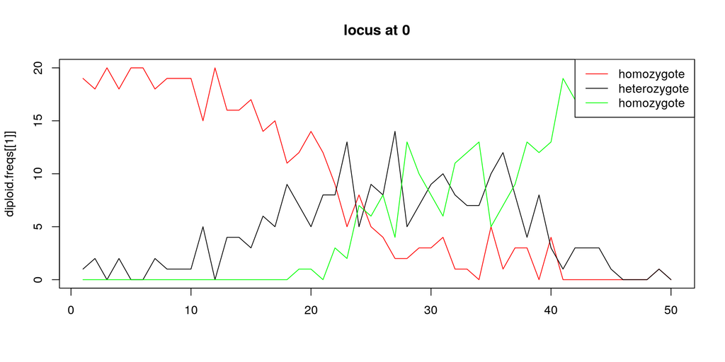

```r
diploid.freqs <- lapply( seq_along(loci), function (locus) {
                do.call( rbind, tapply( 1:ncol(genotypes), sim$deme, function (kk) {
                    as.vector( tabulate( 1+genotypes[locus,kk], nbins=3 ) )
                } ) )
           } )
# one end
matplot(diploid.freqs[[1]],type='l',main=paste("locus at",loci[1]),lty=1,col=c('red','black','green'))
legend('topright',lty=1,col=c('red','black','green'),legend=c("homozygote","heterozygote","homozygote"))
```

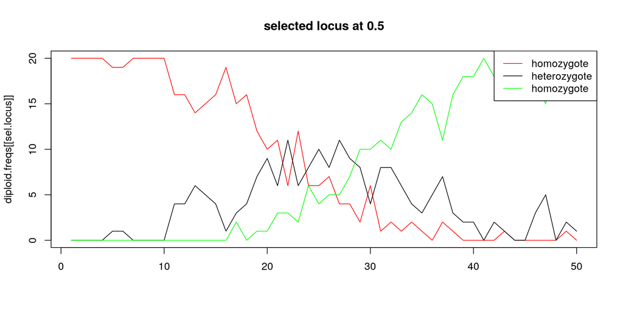

```r
# the selected locus
sel.locus <- match( qtl$chr1$pos, loci )
matplot(diploid.freqs[[sel.locus]],type='l',main=paste("selected locus at",loci[sel.locus]),lty=1,col=c('red','black','green'))
legend('topright',lty=1,col=c('red','black','green'),legend=c("homozygote","heterozygote","homozygote"))
```

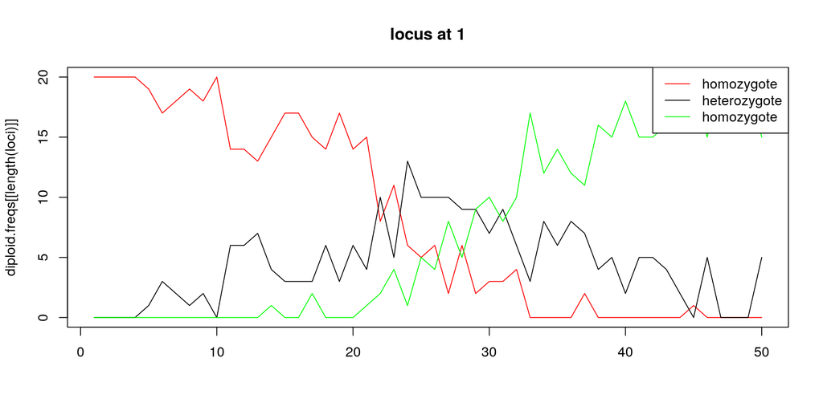

```r
# the other end
matplot(diploid.freqs[[length(loci)]],type='l',main=paste("locus at",loci[length(loci)]),lty=1,col=c('red','black','green'))
legend('topright',lty=1,col=c('red','black','green'),legend=c("homozygote","heterozygote","homozygote"))
```